# Desigualdad de Oportunidad en México

Análisis con ESRU-EMOVI 2023

Eduardo

24 de January de 2026

# Resumen Ejecutivo

Este estudio analiza la **Desigualdad de Oportunidad (IOp)** en México utilizando datos de la Encuesta ESRU-EMOVI 2023. La pregunta central es:

> **¿Qué proporción de la desigualdad de ingresos se debe a circunstancias fuera del control individual?**

## Hallazgos Principales

Modelo

IOp (Gini)

R²

Nota

Random Forest

52.6%

25.9%

Estimación principal

XGBoost (optimizado)

53.5%

34.5%

Con SHAP

Árbol de Decisión

55.4%

28.3%

58 tipos identificados

Gradient Boosting

56.8%

31.2%

RF Cross-Validation

51.5% ± 1.7%

Estimación robusta

**Conclusión Principal:** Aproximadamente **52-57% de la desigualdad de ingresos** en México se debe a circunstancias fuera del control individual como la educación de los padres, el lugar de nacimiento y el sexo.

# 1 Introducción

## 1.1 ¿Qué es la Desigualdad de Oportunidad?

La **Desigualdad de Oportunidad (IOp)** mide qué proporción de la desigualdad total se debe a factores que las personas **no pueden controlar**, llamados **circunstancias**:

- **Parental**: Educación y ocupación de los padres
- **Geográfico**: Región y tipo de localidad donde creciste
- **Demográfico**: Sexo, etnicidad, lengua indígena
- **Socioeconómico**: Recursos del hogar de origen

Bajo el marco de **John Roemer (1998)**, la desigualdad que proviene de estas circunstancias se considera **injusta** o **éticamente inaceptable**, mientras que la desigualdad derivada del esfuerzo individual es considerada “justa”.

## 1.2 Marco Conceptual

$$\text{IOp Share} =
\frac{\text{Desigualdad entre tipos}}{\text{Desigualdad total}} =
\frac{Gini(\mu_{tipos})}{Gini(Y)}$$

Donde un **tipo** es un grupo de personas que comparten las mismas circunstancias.

# 2 Datos y Metodología

## 2.1 Datos Utilizados

| Característica | Valor |
| --- | --- |
| Encuesta | ESRU-EMOVI |
| Año | 2023 |
| Institución | Centro de Estudios Espinosa Yglesias (CEEY) |
| Observaciones totales | 17,843 |
| Casos completos | 13,164 |
| Variable de resultado | Ingreso per cápita del hogar |
| Circunstancias | 9 variables |

## 2.2 Variables de Circunstancias

| Variable | Descripción | Tipo |
| --- | --- | --- |
| educm | Educación de la madre | 4 niveles |
| educp | Educación del padre | 4 niveles |
| clasep | Clase ocupacional del padre | 6 clases |
| sexo | Sexo | Binaria |
| region_14 | Región a los 14 años | 5 regiones |
| p21 | Tipo de localidad a los 14 años | Ciudad/Pueblo/Rural |
| cohorte | Cohorte de nacimiento | Grupos de edad |
| p111 | Habla lengua indígena | Sí/No |
| p112 | Tono de piel | Escala 1-11 |

## 2.3 Modelos Utilizados

[output not shown]

# 3 Resultados de IOp

## 3.1 Estimaciones Principales

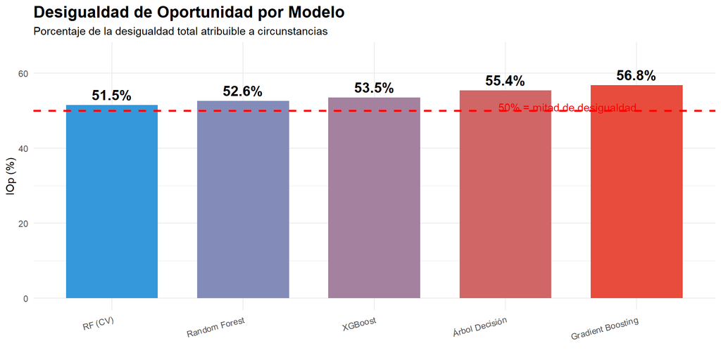

**Interpretación:** Todos los modelos coinciden en que **más de la mitad** de la desigualdad de ingresos se debe a circunstancias. El rango de 51.5% a 56.8% muestra robustez en los resultados.

## 3.2 Comparación con Literatura

Comparación con estudios previos para México

| Estudio | Datos | IOp | Método |
| --- | --- | --- | --- |
| Este estudio | EMOVI 2023 | 52-57% | RF/XGBoost/ctree |
| Monroy-Gómez-Franco (2023) | EMOVI 2017 | ≥48% | Conditional Inference Trees |
| Plassot et al. (2022) | EMOVI 2017 | 45-55% | Machine Learning |

Nuestros resultados son **consistentes** con la literatura previa y ligeramente superiores, lo cual podría reflejar mayor precisión metodológica o cambios reales entre 2017 y 2023.

# 4 Importancia de las Circunstancias

## 4.1 Variable Importance (Random Forest)

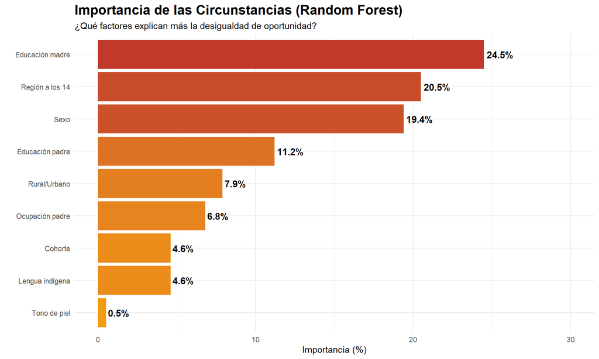

## 4.2 SHAP Values (XGBoost)

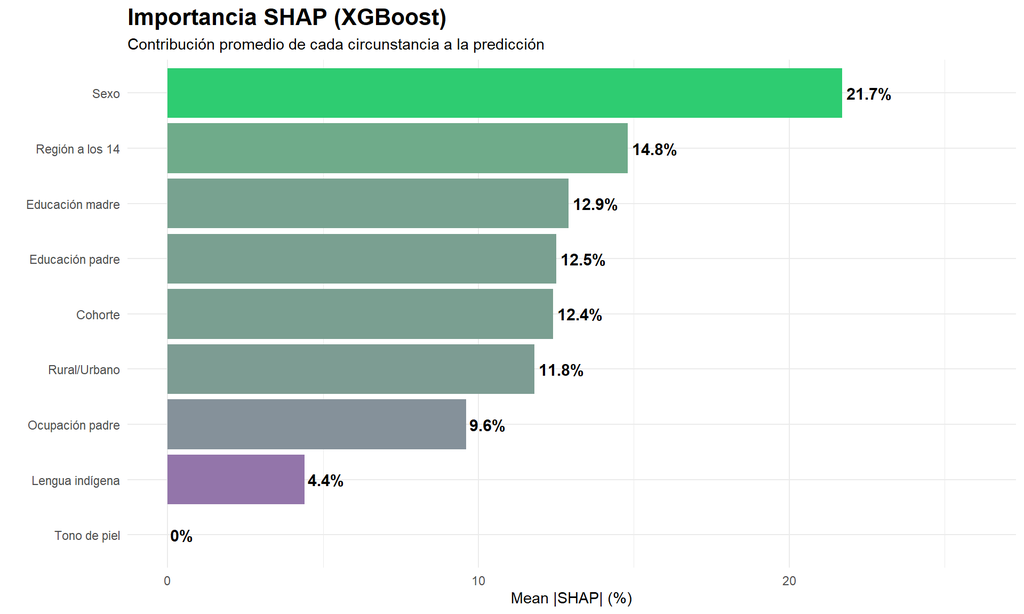

## 4.3 Comparación de Métodos

| Ranking | Random Forest | SHAP (XGBoost) |
| --- | --- | --- |
| 1 | Educación madre (24.5%) | Sexo (21.7%) |
| 2 | Región (20.5%) | Región (14.8%) |
| 3 | Sexo (19.4%) | Educación madre (12.9%) |
| 4 | Educación padre (11.2%) | Educación padre (12.5%) |
| 5 | Rural/Urbano (7.9%) | Cohorte (12.4%) |

**Hallazgo clave:** Ambos métodos coinciden en los principales factores (educación de padres, región, sexo), aunque difieren en su ordenamiento. SHAP revela que el **sexo tiene un efecto directo más fuerte** sobre el ingreso.

# 5 Ingreso Promedio por Circunstancia

## 5.1 Educación de la Madre

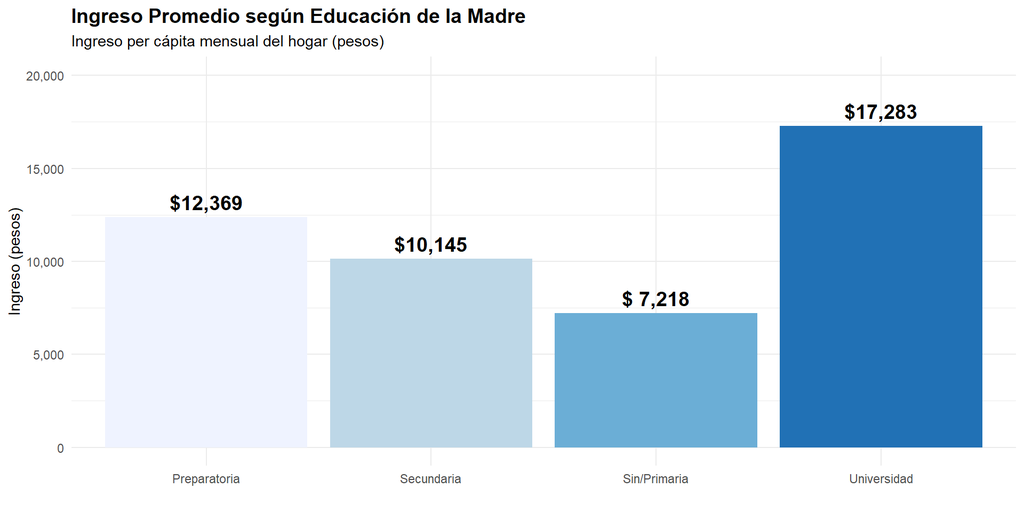

Educación Madre

Ingreso Promedio

vs Sin/Primaria

Sin/Primaria

$ 7,218

Secundaria

$10,145

+41%

Preparatoria

$12,369

+71%

Universidad

$17,283

+139%

**Interpretación:** Una persona cuya madre tiene **universidad** gana **$17,283** vs **$7,218** de quien tiene madre sin primaria. Eso es **2.4 veces más** — una diferencia de **$10,065 pesos mensuales** determinada únicamente por la educación de la madre.

## 5.2 Educación del Padre

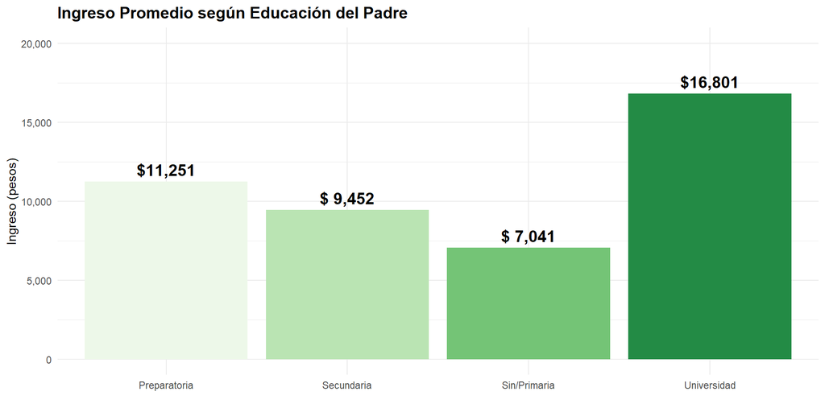

**Brecha:** Universidad vs Sin primaria = **2.4x más** ($9,760 de diferencia)

## 5.3 Sexo

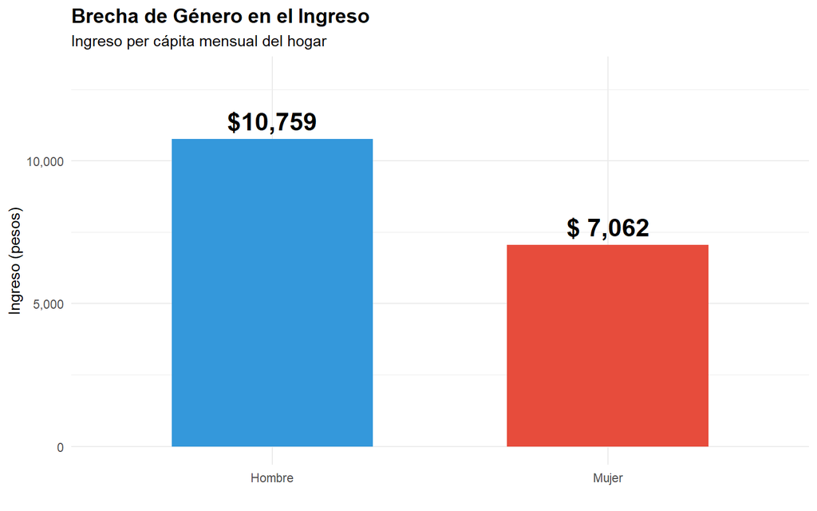

## 5.4 Región a los 14 años

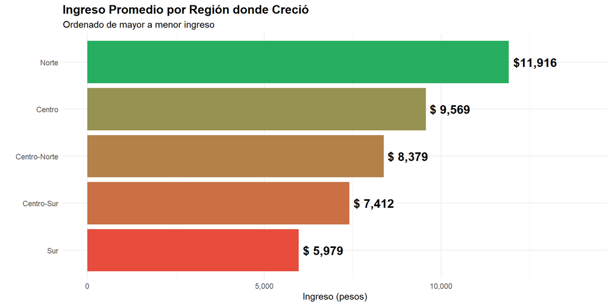

**Brecha regional:** Norte vs Sur = **2.0x más** ($5,937 de diferencia)

## 5.5 Rural / Urbano

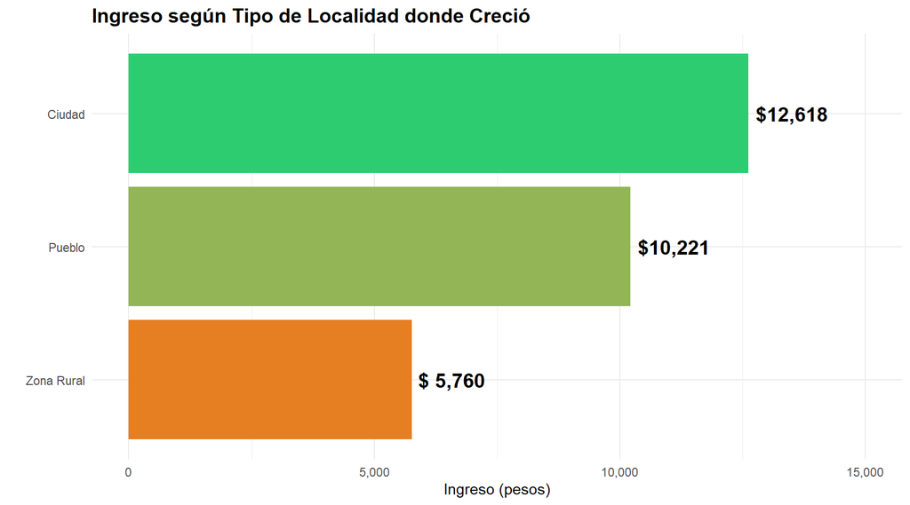

**Brecha urbano-rural:** Ciudad vs Zona Rural = **2.2x más** ($6,858 de diferencia)

## 5.6 Clase Ocupacional del Padre

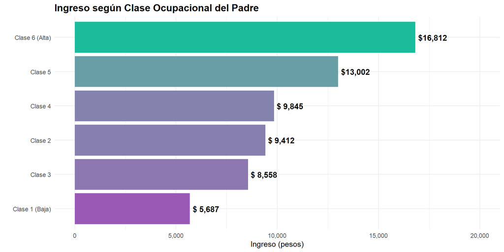

**Brecha ocupacional:** Clase Alta vs Clase Baja = **3.0x más** ($11,125 de diferencia)

## 5.7 Lengua Indígena

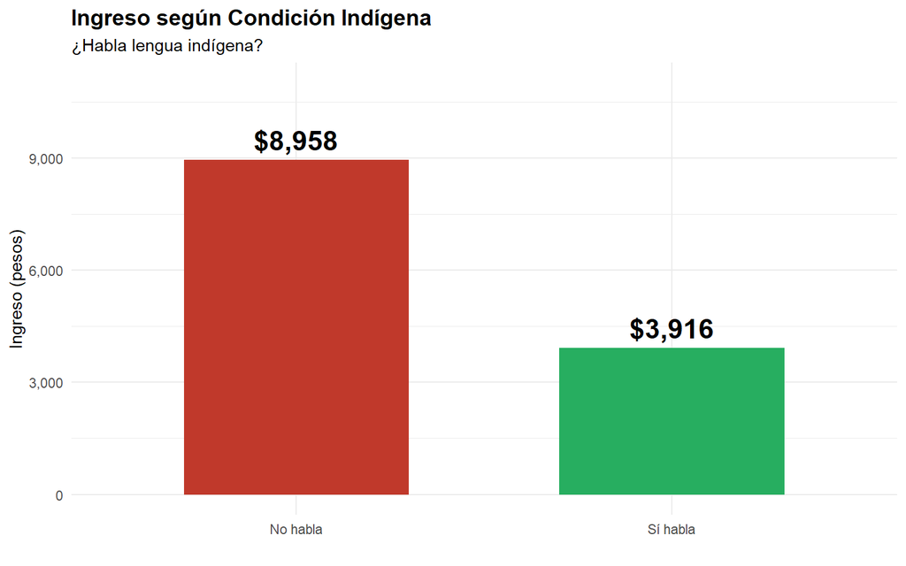

**Brecha étnica:** Quienes **no hablan** lengua indígena ganan **2.3x más** ($5,042 de diferencia). Esta es una de las brechas más pronunciadas.

# 6 Resumen de Brechas

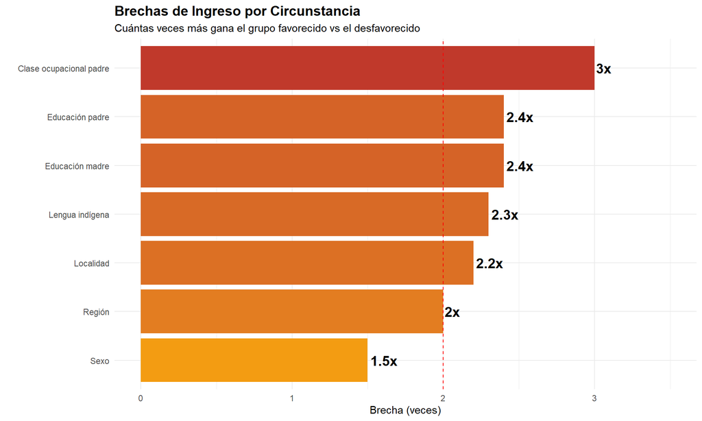

| Circunstancia | Brecha | Diferencia en pesos |
| --- | --- | --- |
| Clase ocupacional padre | 3x | $11,125 |
| Educación madre | 2.4x | $10,065 |
| Educación padre | 2.4x | $ 9,760 |
| Lengua indígena | 2.3x | $ 5,042 |
| Localidad | 2.2x | $ 6,858 |
| Región | 2x | $ 5,937 |
| Sexo | 1.5x | $ 3,697 |

# 7 Visualización del Árbol de Decisión

El árbol de decisión particiona la población en **58 tipos** basados en circunstancias. Cada tipo representa un grupo de personas con características similares y expectativas de ingreso similares.

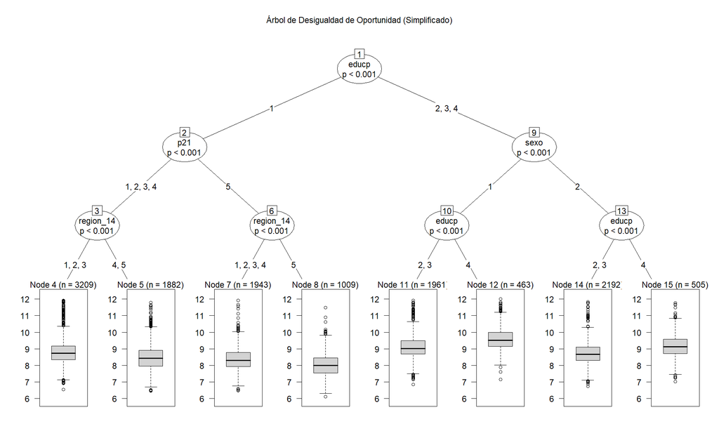

Árbol de decisión simplificado

**Cómo leer el árbol:**

- Cada **nodo interno** muestra una variable y la condición de división
- Cada **nodo terminal** (hoja) representa un “tipo” con su distribución de ingreso
- El árbol revela qué combinaciones de circunstancias determinan el ingreso esperado

# 8 Análisis SHAP

Los valores SHAP (SHapley Additive exPlanations) muestran cómo cada circunstancia contribuye a la predicción del ingreso para cada individuo.

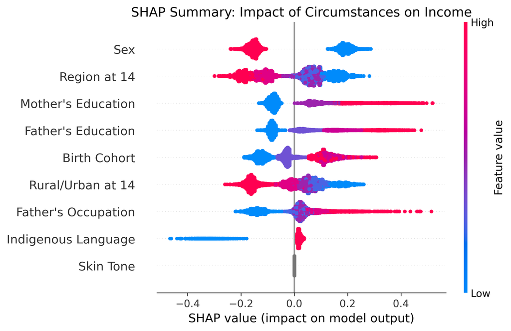

SHAP Summary Plot - Distribución de efectos por circunstancia

**Interpretación del SHAP plot:**

- Cada punto es una persona
- El color indica el valor de la circunstancia (rojo = alto, azul = bajo)
- La posición horizontal indica el impacto en la predicción
- Circunstancias con puntos más dispersos tienen mayor importancia

# 9 Conclusiones

## 9.2 Implicaciones de Política

Para reducir la desigualdad de oportunidad en México se necesitan políticas enfocadas en:

| Área | Políticas Sugeridas |
| --- | --- |
| **Educación** | Ampliar acceso a educación superior, especialmente para mujeres y zonas marginadas |
| **Desarrollo Regional** | Inversión en infraestructura y empleo en el Sur y Centro-Sur |
| **Equidad de Género** | Políticas de igualdad salarial, licencias parentales equitativas |
| **Pueblos Indígenas** | Programas de inclusión económica, educación bilingüe |
| **Primera Infancia** | Intervenciones tempranas para nivelar el campo de juego |

## 9.3 Limitaciones

- El análisis captura **correlaciones**, no necesariamente causalidad
- Algunas circunstancias pueden estar correlacionadas entre sí
- El IOp estimado es un **límite inferior** de la verdadera desigualdad de oportunidad
- Variables no observadas podrían aumentar la estimación de IOp

# 10 Referencias

- Brunori, P., Ferreira, F. H., & Peragine, V. (2023). Inequality of opportunity, measurement and policy implications. *Journal of Economic Inequality*.
- Monroy-Gómez-Franco, L. (2023). A Note on Ex-ante Inequality of Opportunity across Mexican Regions. *Economics Bulletin*, 43(1), 295-301.
- Plassot, T., Soloaga, I., & Torres López, E. (2022). Inequality of Opportunity in Mexico and its Regions. *Journal of Development Studies*.
- Roemer, J. E. (1998). *Equality of Opportunity*. Harvard University Press.
- CEEY (2023). Encuesta ESRU de Movilidad Social en México (EMOVI) 2023.

# 11 Anexos

## 11.1 Código y Reproducibilidad

Todo el código y datos procesados están disponibles en:

**GitHub:** https://github.com/Lalitronico/IOP-Analysis-ESRU-EMOVI-2023

## 11.2 Información de la Sesión

```r
R.version.string
```

```
## [1] "R version 4.5.2 (2025-10-31 ucrt)"
```

```r
Sys.Date()
```

```
## [1] "2026-01-24"
```

*Reporte generado automáticamente. Análisis realizado con R y Python.*

*Datos: ESRU-EMOVI 2023, Centro de Estudios Espinosa Yglesias (CEEY).*